# Week 3 - Graph Visualization

### Week 3 - Graph Visualization

First import necessary packages for plotting graphs using NetworkX and Matplotlib and set up graph size parameters...

```python
import networkx as nx
import matplotlib.pyplot as plt
%matplotlib inline
plt.rcParams["figure.figsize"] = (15,12)
```

### Dolphins

[figure not shown]

Read in "mammalia-dolphin-florida-social.edges" data file from:

```
  @inproceedings{nr-aaai15,
      title = {The Network Data Repository with Interactive Graph Analytics and Visualization},
      author = {Ryan A. Rossi and Nesreen K. Ahmed},
      booktitle = {AAAI},
      url = {http://networkrepository.com},
      year = {2015}
  }
```

```python
dolphins = nx.read_edgelist('mammalia-dolphin-florida-social/mammalia-dolphin-florida-social.edges', nodetype=int,
                                     data=(('weight',int),))
```

Draw the network using NetworkX...

Note that one line containing "37 85 1" was removed from the edges file beccause there were no edges between those two dolphins (numbers 37 and 85) and the rest of the graph. They were far off on the side and it made the rest of the graph hard to visualize.

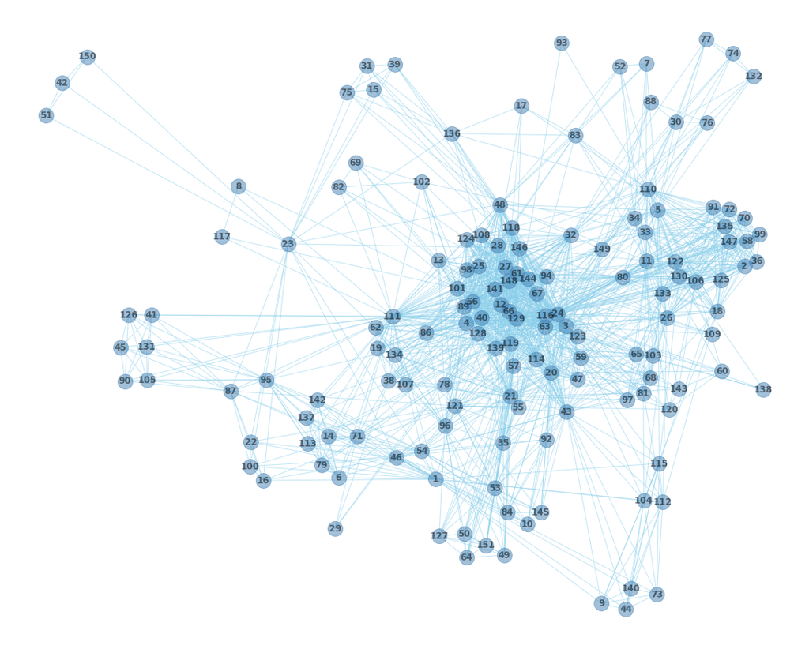

```python
nx.draw(dolphins, with_labels=True, node_color="steelblue", node_size=400, font_weight='bold',
        edge_color="skyblue", alpha=0.5)
```

The most interesting insight that immediately pops out from the graph is that there are 3 dolphins numbers 42, 51 and 150, that are only connected to the rest of the pod through one single other dolphin, number 23. All 3 are connected to each other and to 23 but not to any other dolphin in the pod.

Only one other dolphin seems to be even more isolated with less connections than 42, 51 and 150 who have 3 connections each. Number 93 only has connections with 2 other dolphins in the pod total, numbers 57 and 110. But those two are well connected to the rest of the pod.

Two more dolphins, numbers 8 and 117 also have only 3 connections each, but unlike 42, 51 and 150 they each have connections to 2 other well-connected dolphins and each other.

This structure looks a lot like I would guess some human networks might look. There are some outlier "loner" or "outcast" dolphins who have limited social connections compared to the majorty of their peers.

### Macaques

[figure not shown]

Read in "mammalia-macaque-dominance.edges" data file from:

```
  @inproceedings{nr-aaai15,
      title = {The Network Data Repository with Interactive Graph Analytics and Visualization},
      author = {Ryan A. Rossi and Nesreen K. Ahmed},
      booktitle = {AAAI},
      url = {http://networkrepository.com},
      year = {2015}

  }
```

```python
macaques = nx.read_edgelist('mammalia-macaque-dominance/mammalia-macaque-dominance.edges', nodetype=int,
                                     data=(('weight',int),))
```

Draw the network using NetworkX...

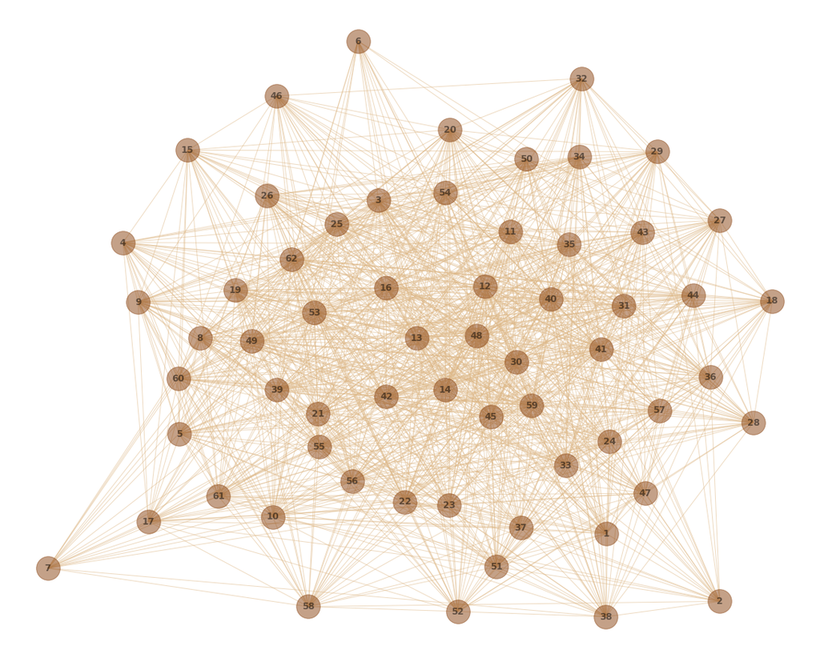

```python
nx.draw(macaques, with_labels=True, node_color="saddlebrown", node_size=1000, font_weight='bold',
        edge_color="burlywood", alpha=0.5)
```